# Correlation Exploration: Heatmaps, scatter plots and other fun things

#### Tissue Annotation:

Here we can use the same annotation functions as in Heatmap with 30 Biomarkers and 59 cell lines: cor1_tissue_an and cor1_colour.

#####Heatmap for a 100 Biomarkers

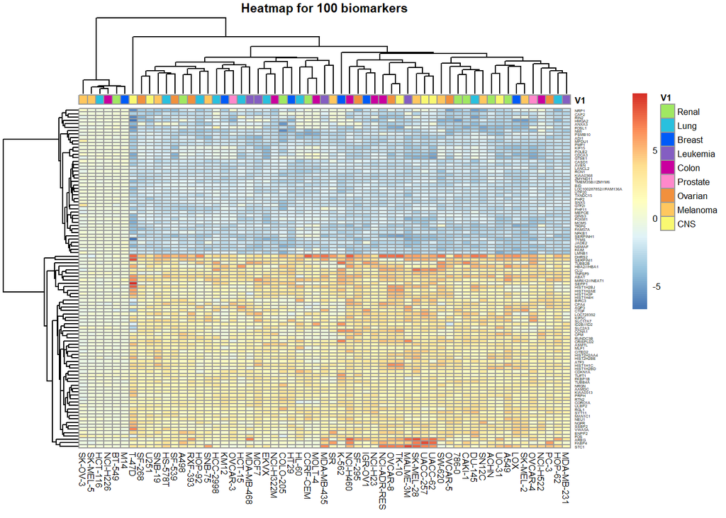

```r
cor1.2 = pheatmap(cor1.2_tab,
                  annotation_colors = cor1_colour,
                  annotation_col = cor1_tissue_an,
                  fontsize = 6.5,
                  fontsize_row= 2.7,
                  fontsize_col = 6,
                  gaps_col=50,
                  info = TRUE,
                  main = "Heatmap for 100 biomarkers"
                  )
```

#####Heatmap with breaks

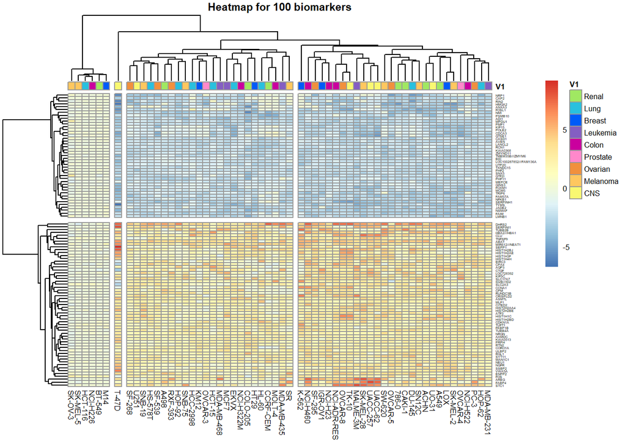

```r
pheatmap(cor1.2_tab,
         annotation_colors = cor1_colour,
         annotation_col = cor1_tissue_an,
         fontsize = 6.5,
         fontsize_row= 2.7,
         fontsize_col = 6,
         gaps_col=50,
         info = TRUE,
         cutree_rows = 2,
         cutree_cols = 4,
         main = "Heatmap for 100 biomarkers"
         )
```

Perhaps one of the most interesting things about this heatmap, is that there is a cluster comprised of a single cell line. Another eye-catching characteristic of this heatmap is that, just as the one for 30 biomarkers, is that there is a cluster that includes cell lines with relative levels of expression close to 0. FUrthermore, we see that some, but not all, melanoma cells are very up-regulated. Although the clustering allows us to better visualize the relationships between cell lines and between biomarkers, no pattern arises and therefore we can say, with the data we have, that the treatment with vorinostat was not better for some types of cancer.

### 2.3 Dendrogram

#### 2.3.1 Dendrogram with 30 Biomarkers and 59 cell lines

### BIOMARKERS

#### ggplot integration

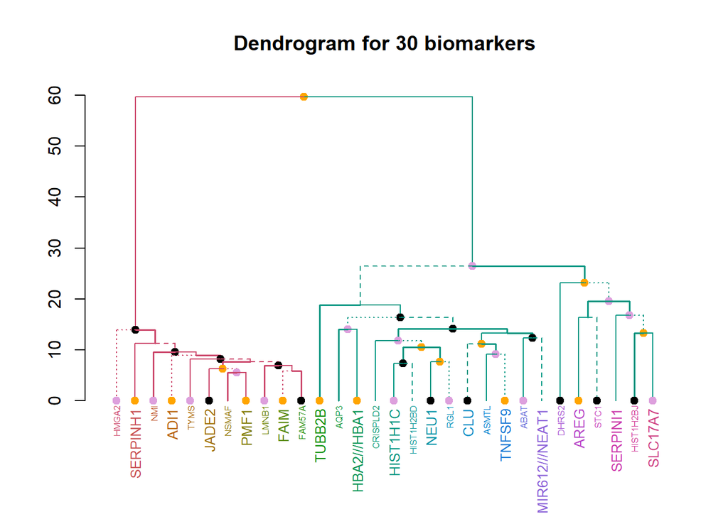

```r
d_gg30 <- cor1_tab %>% dist %>% hclust %>% as.dendrogram %>%
  set("branches_k_color", k=2) %>% set("branches_lwd", c(1.5,1,1)) %>%
  set("branches_lty", c(1,1,3,1,1,2)) %>%
  set("labels_colors") %>% set("labels_cex", c(.5,0.8)) %>%
  set("nodes_pch", 19) %>% set("nodes_col", c("orange", "black", "plum", NA),
  )

plot(d_gg30,
     main = "Dendrogram for 30 biomarkers")
```

#### Polar dendrogram

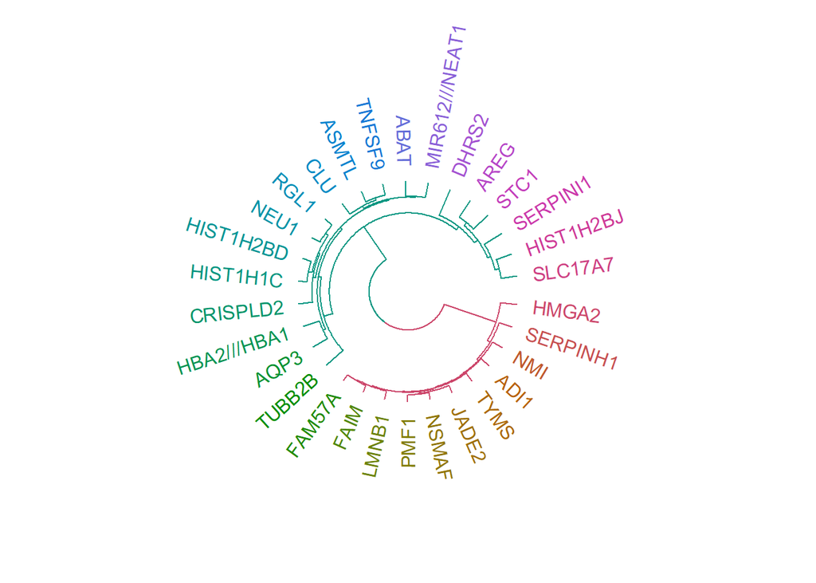

```r
hc_pd <- hclust(dist(cor1_tab))
d_pd <- as.dendrogram(hc_pd)

d_pd30 <- d_pd %>%
  color_branches(k=2) %>%
  color_labels

par(mar = rep(0,4))
circlize_dendrogram(d_pd30,
                    labels_track_height = NA,
                    dend_track_height = .3)
```

#### Retrieving hierachical clustering from the heatmap

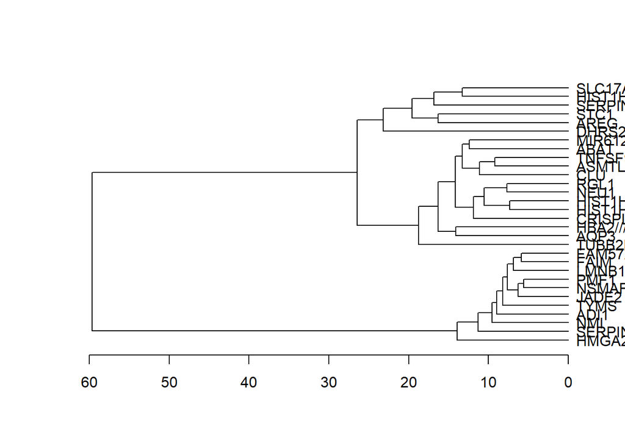

```r
cor1_ret_hclust <- pheatmap(cor1_tab, silent = TRUE)

hc_hmd <- hclust(dist(cor1_tab), "ave")
cor1_ret_hclust$tree_row %>%
  as.dendrogram() %>%
  plot(horiz = TRUE)
```

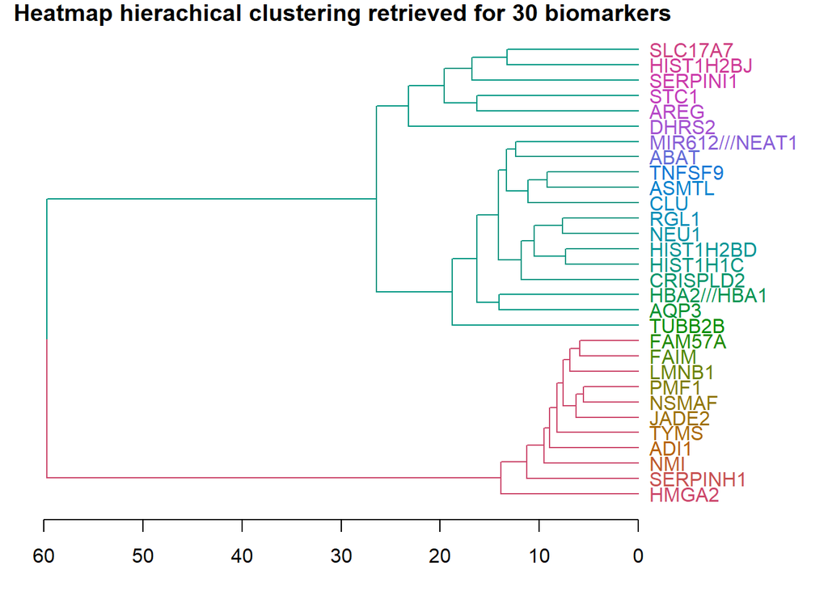

```r
cor1_ret_hclust$tree_row = cor1_ret_hclust$tree_row %>% color_branches(k=2) %>% color_labels

par(mar = c(3,1,1,7))
plot(cor1_ret_hclust$tree_row,
     horiz  = TRUE,
     main = "Heatmap hierachical clustering retrieved for 30 biomarkers")
```

### CELL LINES

#### ggplot integration

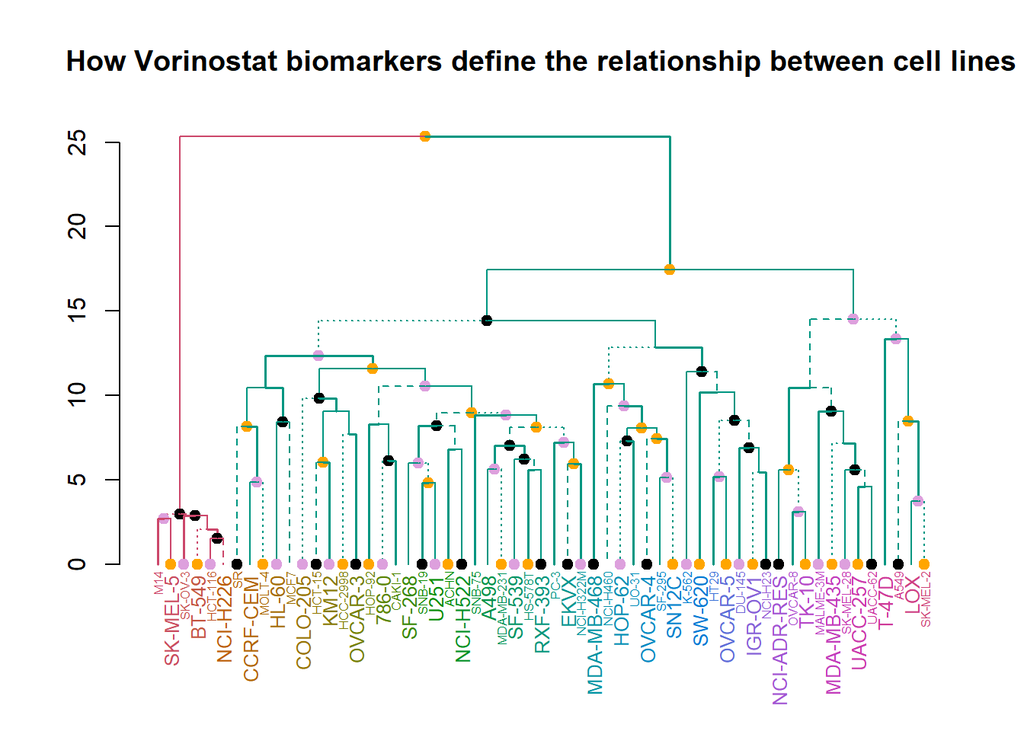

```r
d_gg30t <- t(cor1_tab) %>% dist %>% hclust %>% as.dendrogram %>%
  set("branches_k_color", k=2) %>% set("branches_lwd", c(1.5,1,1)) %>%
  set("branches_lty", c(1,1,3,1,1,2)) %>%
  set("labels_colors") %>% set("labels_cex", c(.5,0.8)) %>%
  set("nodes_pch", 19) %>% set("nodes_col", c("orange", "black", "plum", NA)
  )

plot(d_gg30t,
      main = "How Vorinostat biomarkers define the relationship between cell lines")
```

#### Polar dendrogram

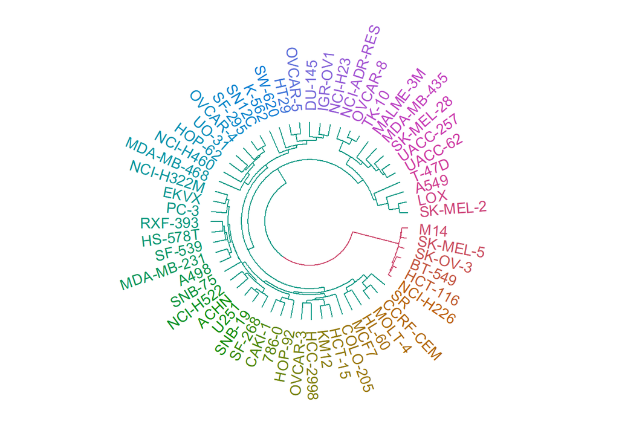

```r
hc_pd <- hclust(dist(t(cor1_tab)))
d_pd <- as.dendrogram(hc_pd)

d_pd30t <- d_pd %>%
  color_branches(k=2) %>%
  color_labels

par(mar = rep(0,4))
circlize_dendrogram(d_pd30t, labels_track_height = NA, dend_track_height = .3)
```

#### Retrieving hierachical clustering from the heatmap

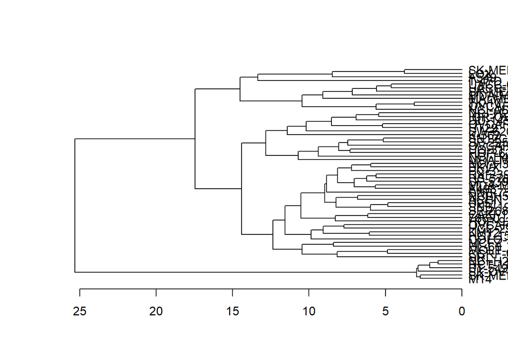

```r
cor1_ret_hclust <- pheatmap(t(cor1_tab), silent = TRUE)

hc_hmd <- hclust(dist(t(cor1_tab)), "ave")
cor1_ret_hclust$tree_row %>%
  as.dendrogram() %>%
  plot(horiz = TRUE)
```

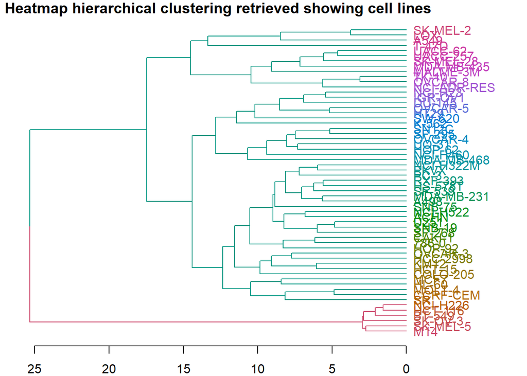

```r
cor1_ret_hclust$tree_row = cor1_ret_hclust$tree_row %>% color_branches(k=2) %>% color_labels

par(mar = c(2,1,1,7))
plot(cor1_ret_hclust$tree_row, horiz  = TRUE,
     main = "Heatmap hierarchical clustering retrieved showing cell lines")
```

#### 2.3.2 Dendrogram with 100 Biomarkers and 59 cell lines

### BIOMARKERS

#### ggplot integration

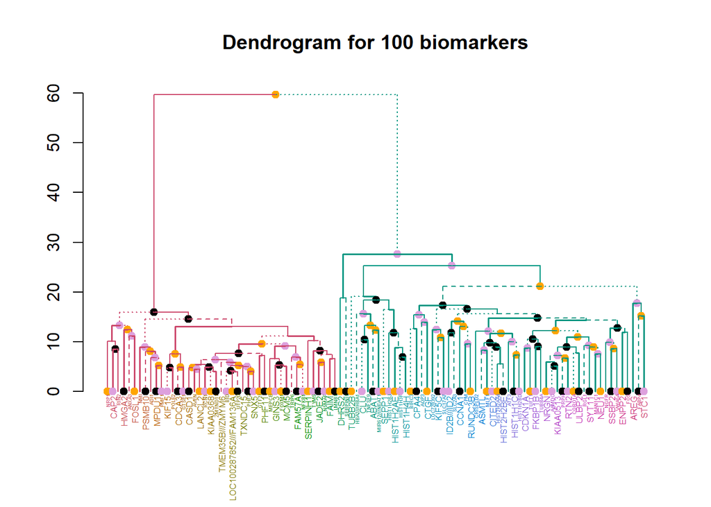

```r
d_gg100 <- cor1.2_tab %>% dist %>% hclust %>% as.dendrogram %>%
  set("branches_k_color", k=2) %>% set("branches_lwd", c(1.5,1,1)) %>%
  set("branches_lty", c(1,1,3,1,1,2)) %>%
  set("labels_colors") %>% set("labels_cex", c(0.28,0.5)) %>%
  set("nodes_pch", 19) %>% set("nodes_col", c("orange", "black", "plum", NA)
  )

plot(d_gg100,
     main = "Dendrogram for 100 biomarkers")
```

#### Retrieving hierachical clustering from the heatmap

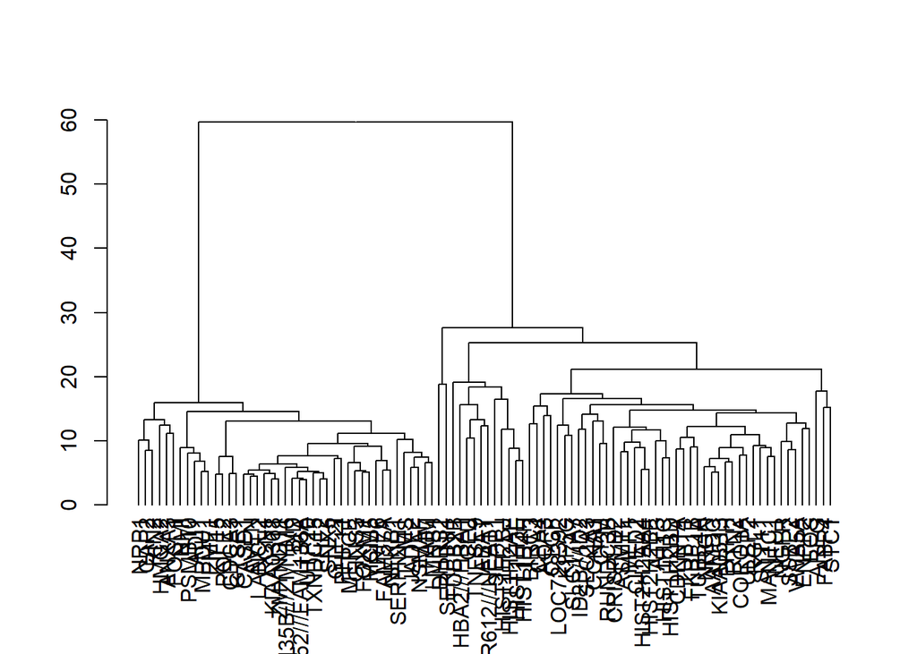

```r
cor1.2_ret_hclust <- pheatmap(cor1.2_tab, silent = TRUE)

hc_hmd <- hclust(dist(cor1.2_tab), "ave")
cor1.2_ret_hclust$tree_row %>%
  as.dendrogram() %>%
  plot()
```

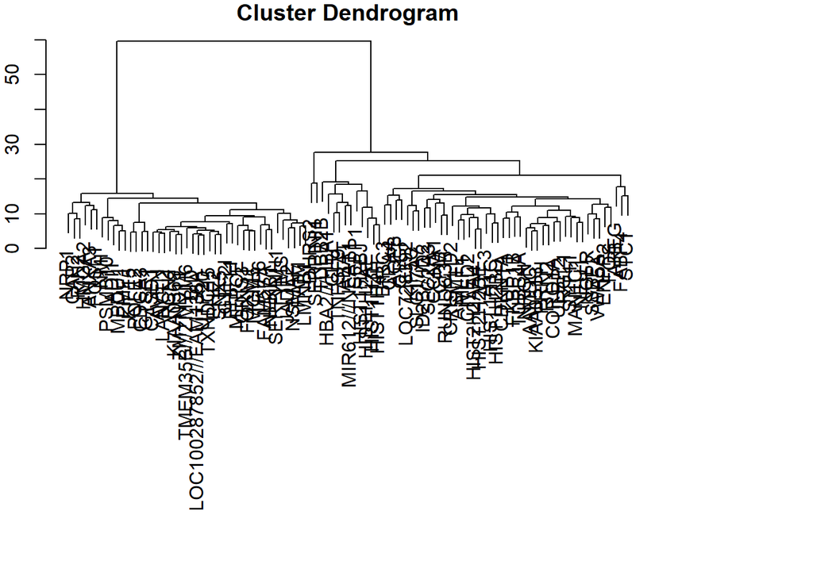

```r
cor1_ret_hclust$tree_row = cor1.2_ret_hclust$tree_row %>% color_branches(k=2) %>% color_labels

par(mar = c(3,2,1,7))
plot(cor1.2_ret_hclust$tree_row)
```

### CELL LINES

#### ggplot integration

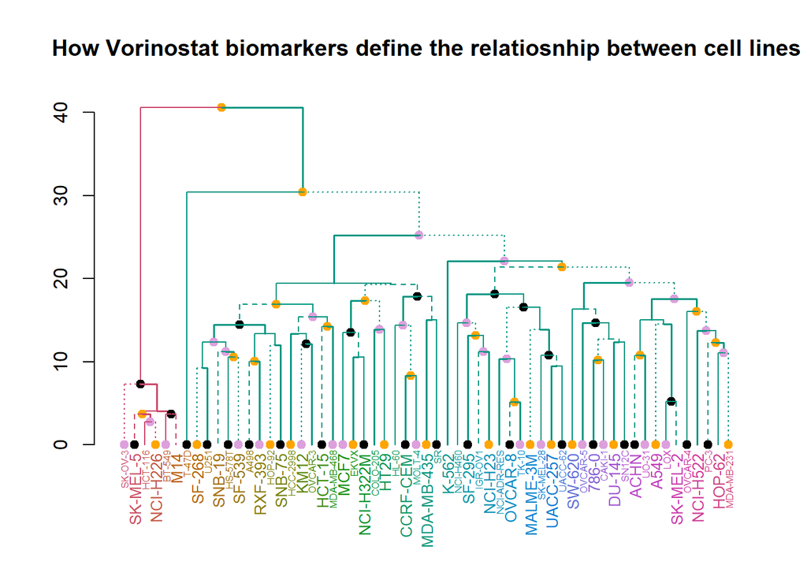

```r
d_gg100t <- t(cor1.2_tab) %>% dist %>% hclust %>% as.dendrogram %>%
  set("branches_k_color", k=2) %>% set("branches_lwd", c(1.5,1,1)) %>%
  set("branches_lty", c(1,1,3,1,1,2)) %>%
  set("labels_colors") %>% set("labels_cex", c(.5,0.8)) %>%
  set("nodes_pch", 19) %>% set("nodes_col", c("orange", "black", "plum", NA)
  )

plot(d_gg100t,
     main = "How Vorinostat biomarkers define the relatiosnhip between cell lines")
```

#### Polar dendrogram

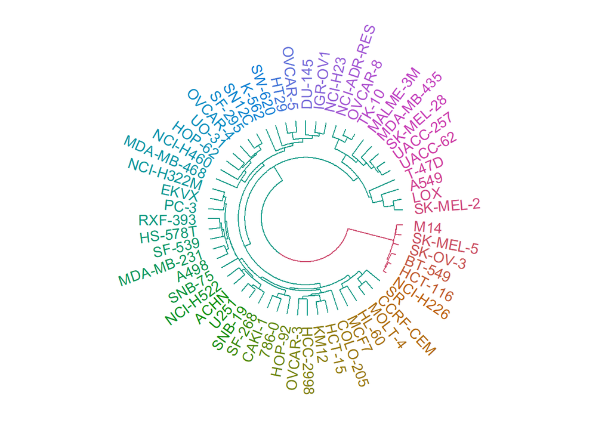

```r
hc_pd <- hclust(dist(t(cor1_tab)))
d_pd <- as.dendrogram(hc_pd)

d_pd100t <- d_pd %>%
  color_branches(k=2) %>%
  color_labels

par(mar = rep(0,4))
circlize_dendrogram(d_pd100t, labels_track_height = NA, dend_track_height = .3)
```

#### Retrieving hierachical clustering from the heatmap

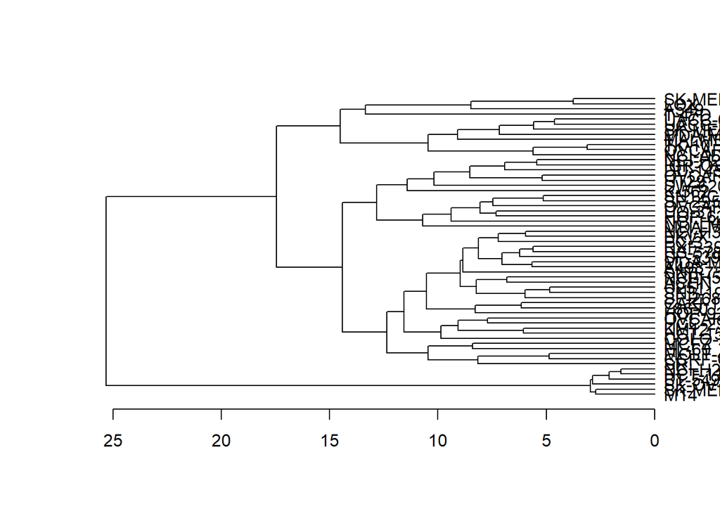

```r
cor1_ret_hclust <- pheatmap(t(cor1_tab), silent = TRUE)

hc_hmd <- hclust(dist(t(cor1_tab)), "ave")
cor1_ret_hclust$tree_row %>%
  as.dendrogram() %>%
  plot(horiz = TRUE)
```

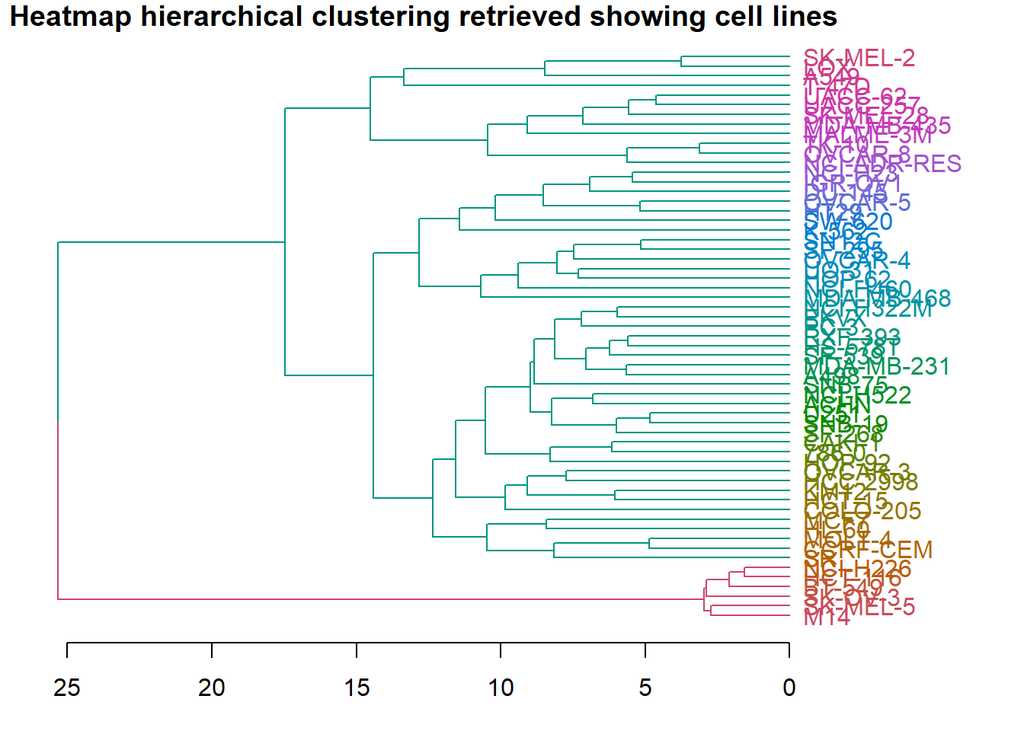

```r
cor1_ret_hclust$tree_row = cor1_ret_hclust$tree_row %>% color_branches(k=2) %>% color_labels

par(mar = c(3,1,1,7))
plot(cor1_ret_hclust$tree_row,
     horiz  = TRUE,
     main = "Heatmap hierarchical clustering retrieved showing cell lines")
```

#### 2.3.3 Comparison of dendrograms with 100 Biomarkers and 30 Biomarkers

##### Comparison of biomarkers

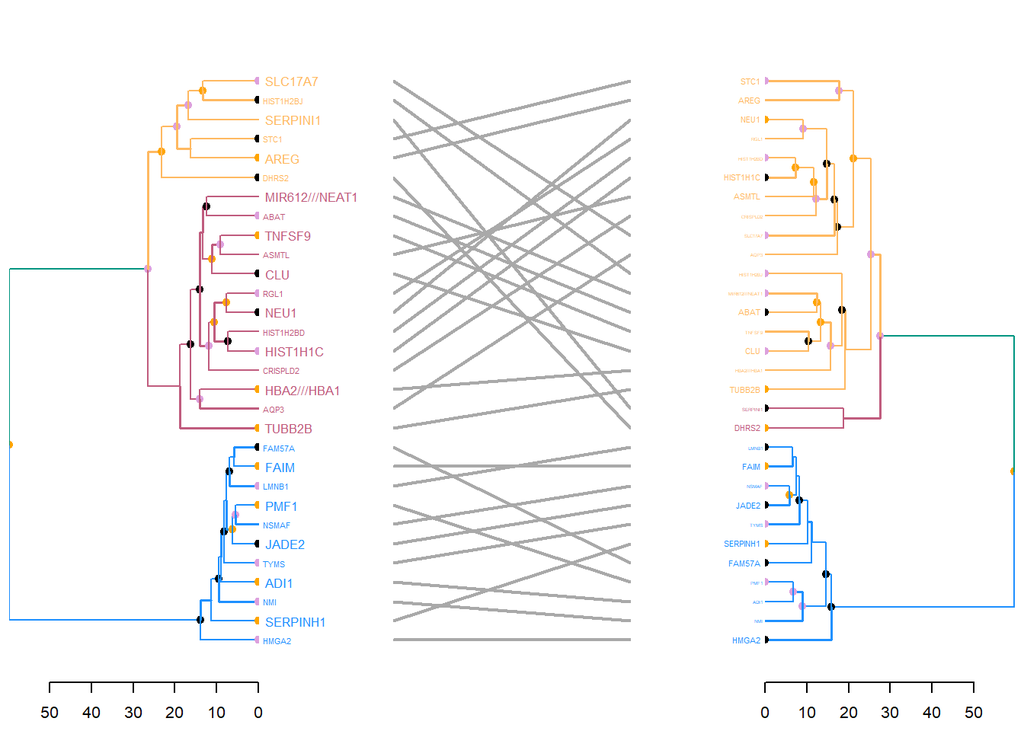

```r
#Creating a dendlist
dl_BM <- dendlist(
  d_gg30 %>%
    set("labels_col", value = c("#1E90FF", "#c05c7e", "#ffb961"), k=3) %>%
    set("branches_lty", 1) %>%
    set("branches_k_color", value = c("#1E90FF", "#c05c7e", "#ffb961"), k = 3),
  d_gg100 %>%
    set("labels_col", value = c("#1E90FF", "#c05c7e", "#ffb961"), k=3) %>%
    set("branches_lty", 1) %>%
    set("branches_k_color", value = c("#1E90FF", "#c05c7e", "#ffb961"), k = 3)
                  )

#Plot both dendograms for comparison
tanglegram(dl_BM,
           common_subtrees_color_lines = FALSE,
           highlight_distinct_edges  = TRUE,
           highlight_branches_lwd=FALSE,
           margin_inner=7,
           lwd=2
           )
```

The trees were pruned because the labels in both dendrograms had different values.

The dendogram on the left corresponds to that of the 30 biomarkers and the one on the right to that of 100 biomarkers. Here we can see increasing the number of biomarkers drasticaclly changes the relationships that arise in our data.

### 2.4 Correlogram and Scatter Plot for 30 Biomarkers and 59 cell lines

#### Correlogram

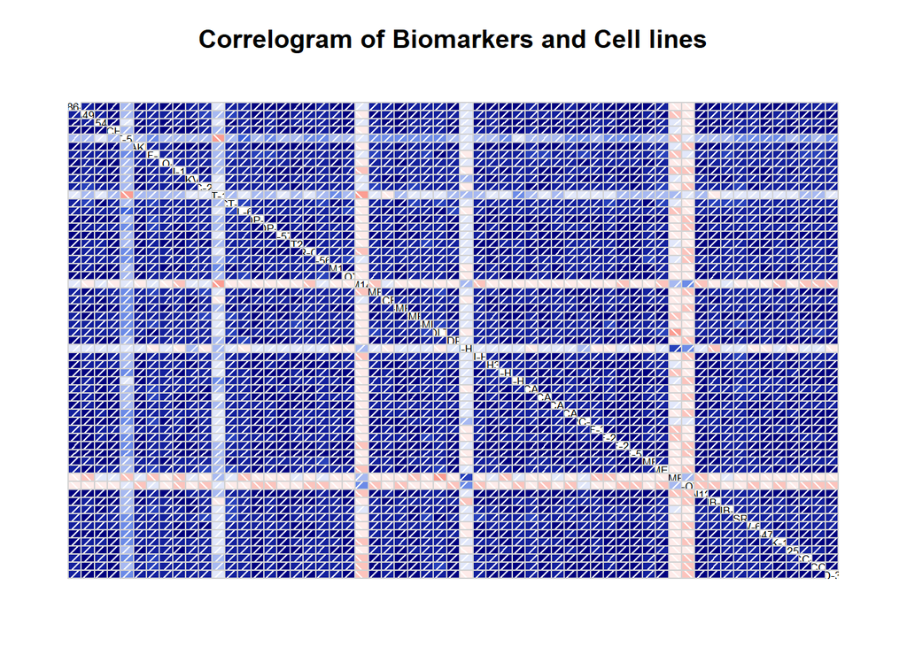

```r
corrgram(cor1_tab, order=NULL, panel=panel.shade, text.panel=panel.txt,
         main="Correlogram of Biomarkers and Cell lines")
```

#### Scatter plots

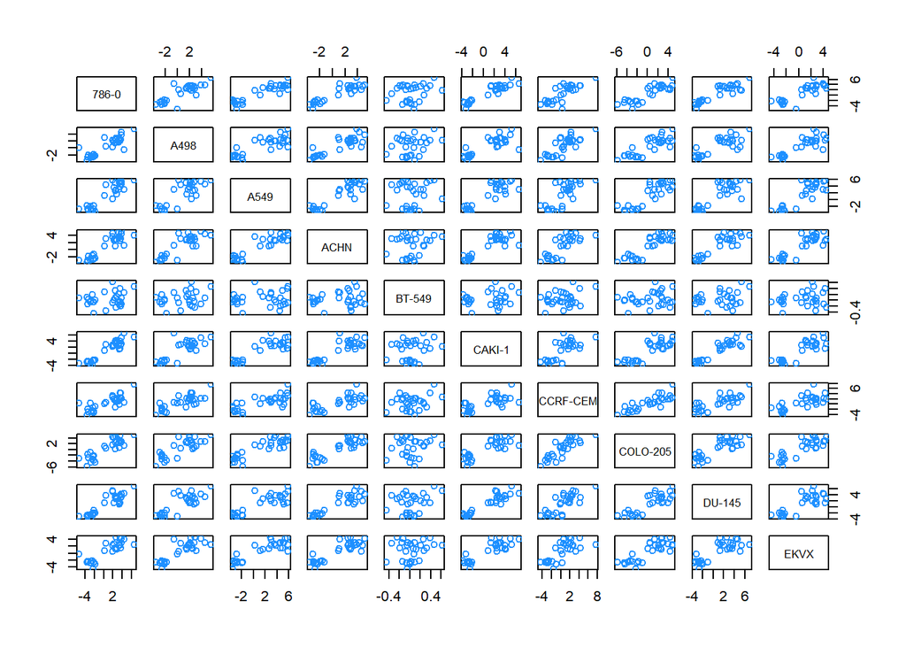

```r
pairs(cor1_tab, horInd = 1:10, verInd = 1:10, col="#1E90FF")
```

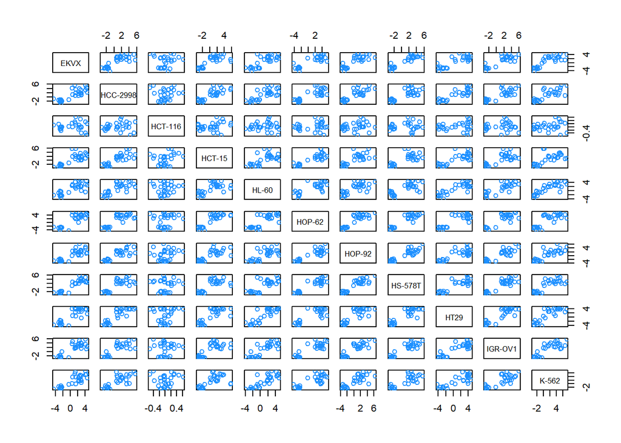

```r
pairs(cor1_tab, horInd = 10:20, verInd = 10:20, col="#1E90FF")
```

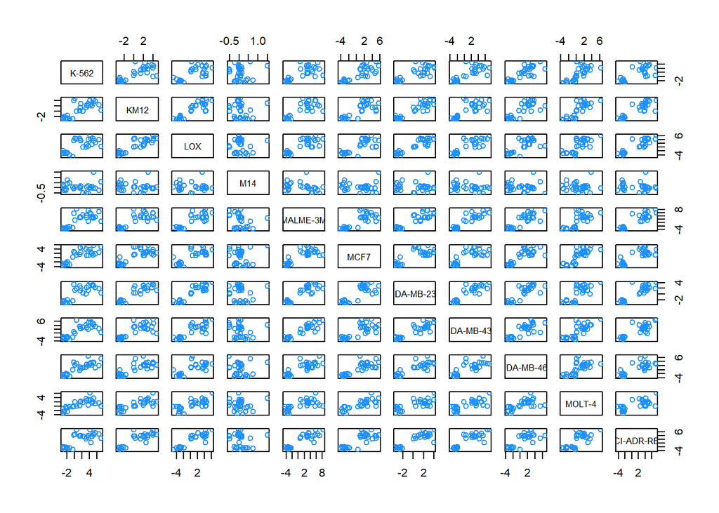

```r
pairs(cor1_tab, horInd = 20:30, verInd = 20:30, col="#1E90FF")
```

The scatter plots lets us get a closer look at the relationship between different cell lines. In this way we can easily observe that some cell lines seem to have a linaer relationship with others, e.g. COLO-205 with CCRF-CEM.

#### Matrix for correlations: with 30 biomarkers and with 100 biomarkers

30 Biomarkers:

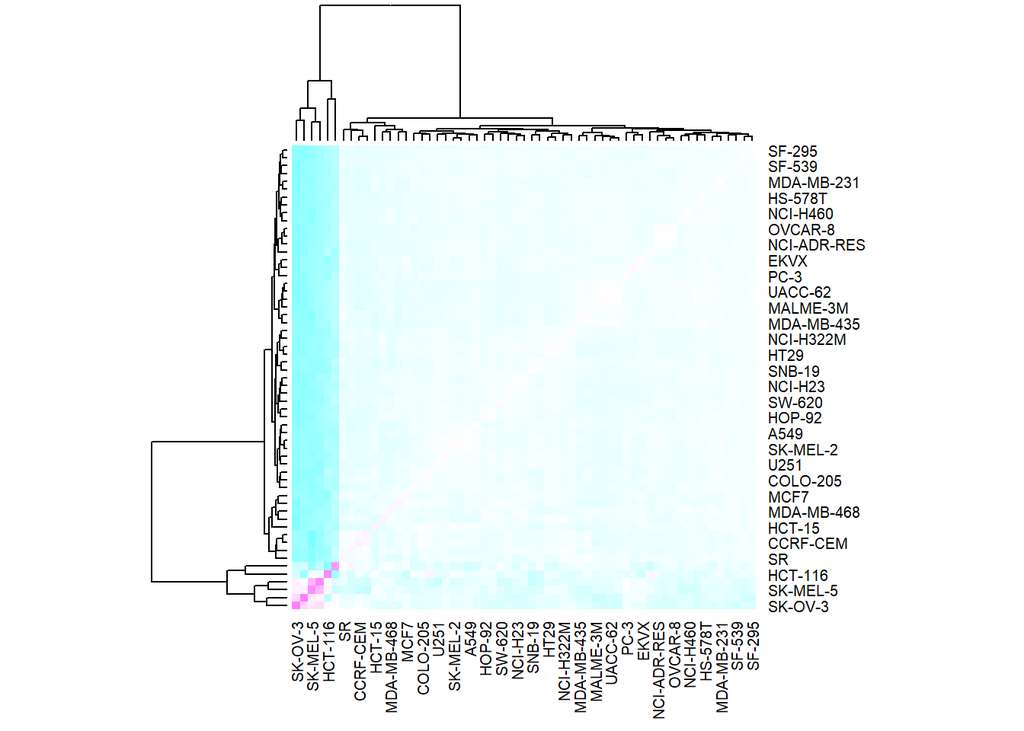

```r
cor = cor(cor1_tab)
heatmap(cor, col = cm.colors(256))
```

100 Biomarkers

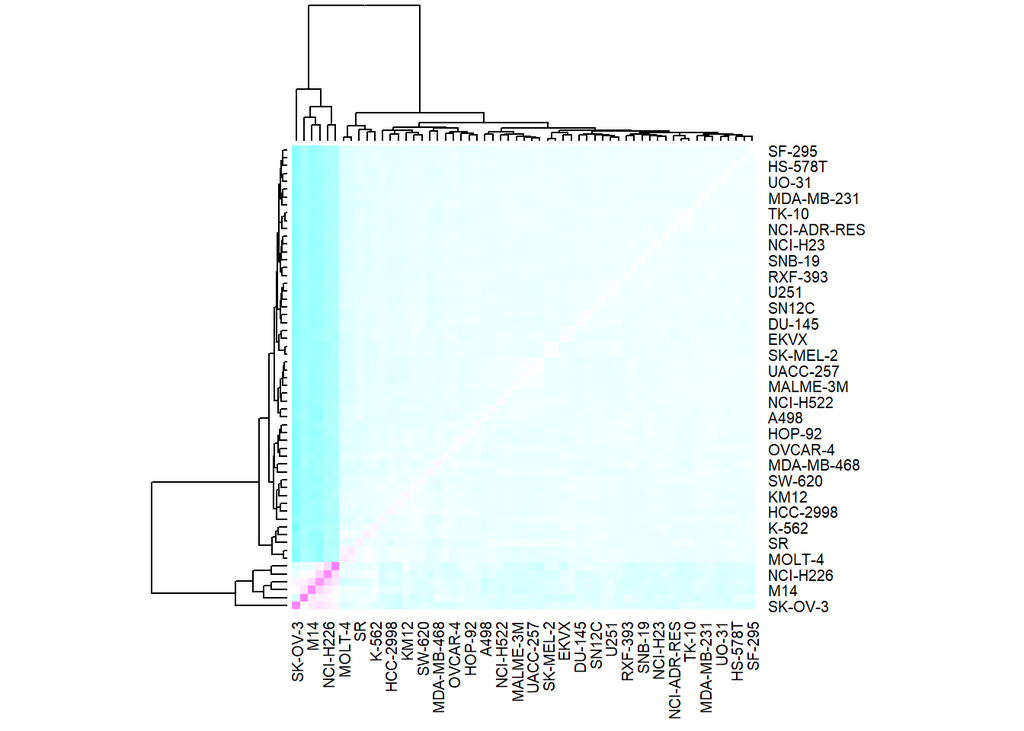

```r
cor1.2 = cor(cor1.2_tab)
heatmap(cor1.2, col = cm.colors(256))
```

Strangely we do not see a correlation value of 1 between the same cell lines. We also see that different patterns of clustering for the cell lines emerge when we consider 100 biomarkers and when we consider 30 biomarkers.